# Workshop 1: Signals in Time Domain

```python
import numpy as np
import matplotlib.pyplot as plt
```

# 1.1 Real CT Sinusoid

$x(t)=A \cos(\omega_ 0 t + \phi)$

## Example 1

Plot of $x(t)=A \cos(\omega_ 0 t + \phi)$ with $\phi = 0$

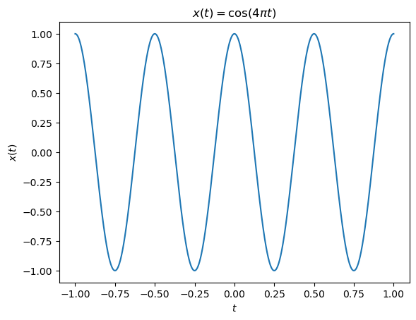

```python
sampling_freq = 44100
sampling_period = 1/sampling_freq

#linearly spaced array with step ts(sampling_period)
t = np.arange(-1,1, sampling_period)

amp = 1
freq = 2
phi = 0
omega0= 2*np.pi*freq

xt0 = amp*np.cos(omega0*t+phi)

fig, ax = plt.subplots()
ax.plot(t,xt0)
ax.set_xlabel(r'$t$')
ax.set_ylabel(r'$x(t)$')
ax.title.set_text(r'$x(t)= \cos (4 \pi t)$')
plt.show()
```

## Task 1

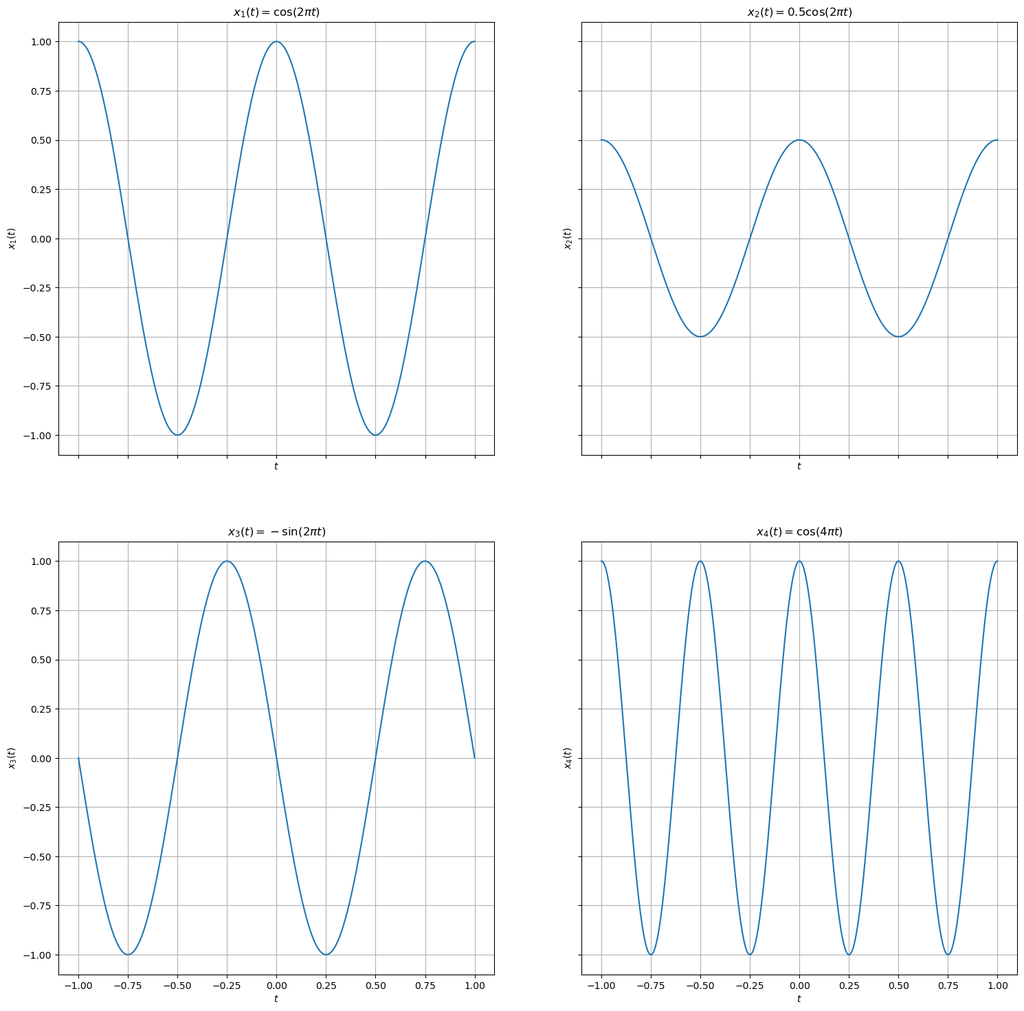

```python
fig, axes = plt.subplots(2,2,sharex='all', sharey='all',figsize=(18,18))

def sinusoid(amp,omega0,phi,t):
    return amp*np.cos(omega0*t+phi)

xt1= sinusoid(1,2*np.pi,0,t)
xt2= sinusoid(0.5,2*np.pi,0,t)
xt3= sinusoid(1,2*np.pi,np.pi/2,t)
xt4= sinusoid(1,4*np.pi,0,t)

# plot xt1
axes[0,0].plot(t,xt1)
axes[0,0].set_xlabel('$t$')
axes[0,0].set_ylabel('$x_1(t)$')
axes[0,0].grid(True)
axes[0,0].title.set_text(r'$x_1(t)=\cos(2\pi t)$')
# plot xt2
axes[0,1].plot(t,xt2)
axes[0,1].set_xlabel('$t$')
axes[0,1].set_ylabel('$x_2(t)$')
axes[0,1].grid(True)
axes[0,1].title.set_text(r'$x_2(t)=0.5 \cos(2\pi t)$')

# plot xt3
axes[1,0].plot(t,xt3)
axes[1,0].set_xlabel('$t$')
axes[1,0].set_ylabel('$x_3(t)$')
axes[1,0].grid(True)
axes[1,0].title.set_text(r'$x_3(t)=-\sin(2\pi t)$')

# plot xt2
axes[1,1].plot(t,xt4)
axes[1,1].set_xlabel('$t$')
axes[1,1].set_ylabel('$x_4(t)$')
axes[1,1].grid(True)
axes[1,1].title.set_text(r'$x_4(t)=\cos(4\pi t)$')
```

#### Even signals

$xt_1 = \cos(2\pi t)$  
$xt_2 = 0.5 \cos(2\pi t)$  
$xt_4 = \cos(4\pi t)$

#### Odd signals

$xt_3 = - \sin(2\pi t)$

## Example 2

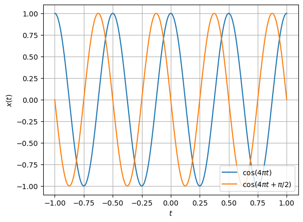

```python
x1t = np.cos(omega0*t+phi)
x2t = np.cos(omega0*t+ np.pi/2)

fig,ax = plt.subplots()
ax.plot(t,x1t, label=r'$\cos(4\pi t)$')
ax.plot(t,x2t, label=r'$\cos(4\pi t + \pi/2)$')

ax.set_xlabel('$t$')
ax.set_ylabel('$x(t)$')
plt.legend(loc='lower right')
ax.grid(True)

plt.show()
```

# 1.2 Real CT Exponential

Plotting $x(t)= C e^{\alpha t}$ with $C = 1.0$ and $\alpha = 1.2$

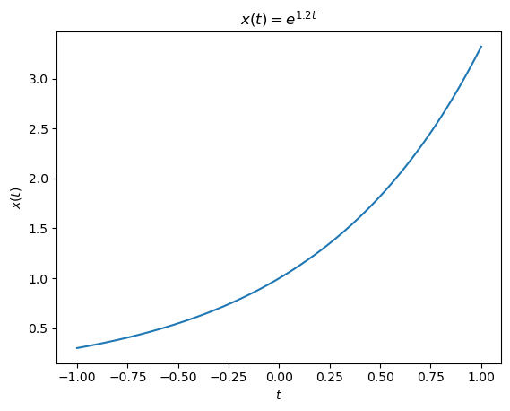

```python
fs = 4.4e4 # sampling frequency
ts = 1/fs # sampling period

t = np.arange(-1,1,ts) # create array spaced evenly by sampling period
c = 1.0
alpha = 1.2

# define a function to return an array of values of a signal at evenly spaced timings
def reat_CT_exp(c,alpha,t):
    """returns a real continous time (CT) exponential signal array"""
    return c*np.exp(alpha*t)

# create real CT exponential with above t,c, alpha values
xt = reat_CT_exp(c,alpha,t)

# plotting the created signal using matplotlib
fig, ax = plt.subplots()
ax.plot(t,xt)
ax.set_xlabel('$t$')
ax.set_ylabel('$x(t)$')
ax.title.set_text('$x(t)= e^{1.2 t}$')
plt.show()
```

### Effect due to the sign of $\alpha$ on the signal

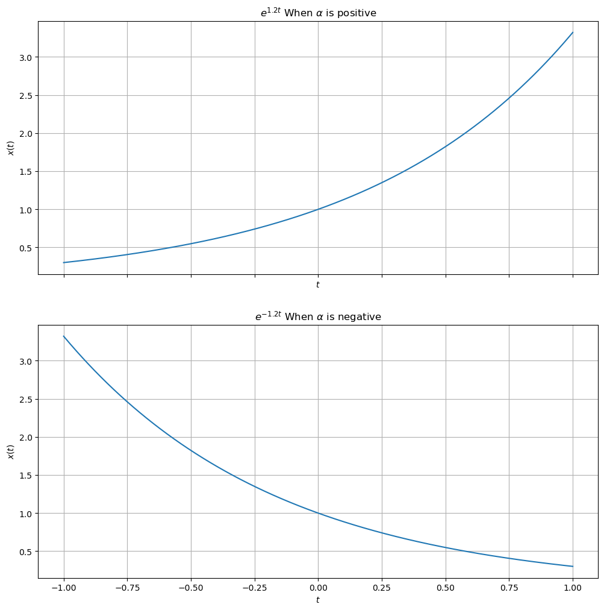

```python
# create two signals to check effect of the sign of alpha
x1t = reat_CT_exp(c, alpha,t)
x0t = reat_CT_exp(c, -alpha,t)

# plotting the signals
fig,ax = plt.subplots(2,1, sharex='all', sharey='all', figsize=(12,12))
# plot x1t
ax[0].plot(t,x1t)
ax[0].set_xlabel('$t$')
ax[0].set_ylabel('$x(t)$')
ax[0].title.set_text(r'$e^{1.2 t}$ When $\alpha$ is positive')
ax[0].grid(True)
# plot x2t
ax[1].plot(t,x0t)
ax[1].set_xlabel('$t$')
ax[1].set_ylabel('$x(t)$')
ax[1].title.set_text(r'$e^{-1.2 t}$ When $\alpha$ is negative')
ax[1].grid(True)

plt.show()
```

Comment: When alpha changes the sign, the signal flips about the y axis. Moreover, when alpha is positive signal is exponentially increasing and when it is negative it is exponentially decaying.

# 1.3 Growing Sinusoidal Signal

$x(t) = Ce^{rt} \cos (\omega t + \theta)$

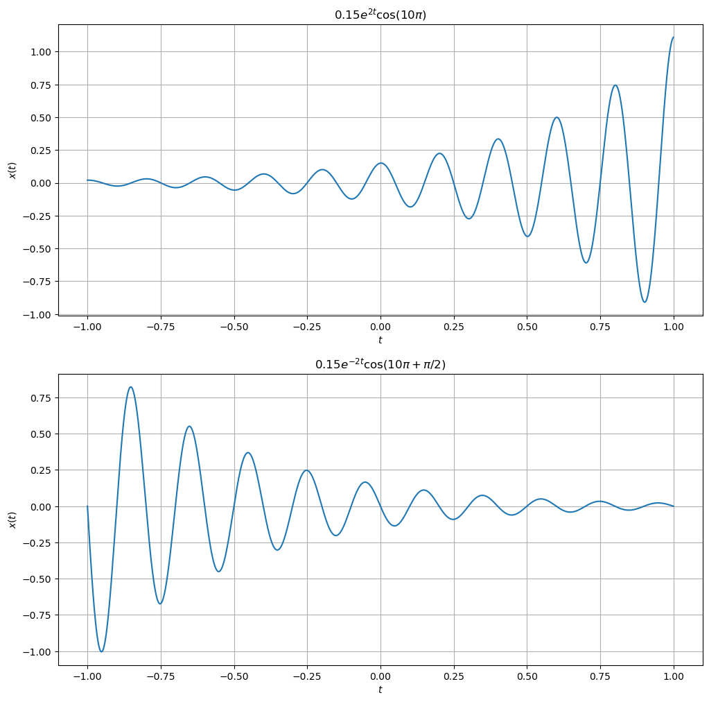

```python
def growing_sinusoid(c, r, theta, t, omeg0):
    """returns a growing sinusoid signal array"""
    return c*np.exp(r*t)*np.cos(omeg0*t + theta)

# define values
f = 5 # frequency is 5 Hz
omeg0=2*np.pi*f # angular frquency

# create two signals
x1t = growing_sinusoid(0.15, 2, 0, t, omeg0)
x2t = growing_sinusoid(0.15, -2, np.pi/2, t, omeg0)

# plotting the signals
fig,ax = plt.subplots(2,1, figsize=(12,12))
# plot x1t
ax[0].plot(t,x1t)
ax[0].set_xlabel('$t$')
ax[0].set_ylabel('$x(t)$')
ax[0].title.set_text(r'$0.15e^{2 t} \cos (10\pi)$')
ax[0].grid(True)
# plot x2t
ax[1].plot(t,x2t)
ax[1].set_xlabel('$t$')
ax[1].set_ylabel('$x(t)$')
ax[1].title.set_text(r'$0.15e^{-2 t} \cos (10\pi + \pi /2)$')
ax[1].grid(True)

plt.show()
```

# 1.4 Real DT Exponential

$x[n] = C \alpha^{n}$

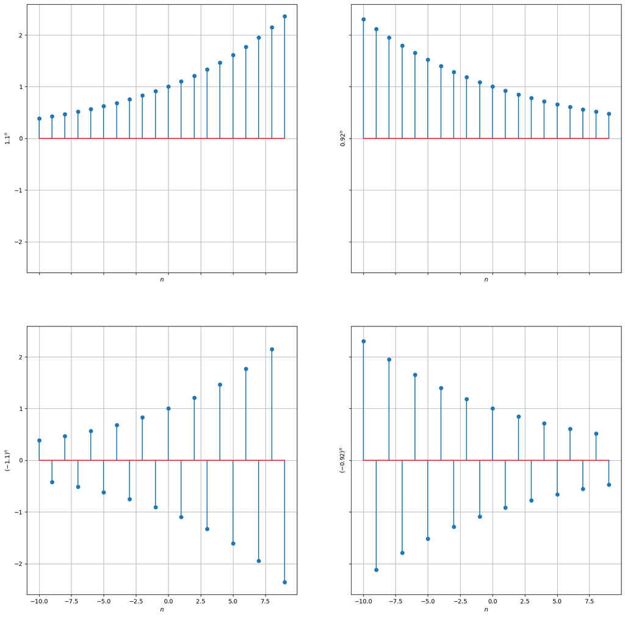

```python
def real_DT_exp(c,alpha,n):
    """returns a real destcrete time (DT) exponential signal array"""
    return c*alpha**n

# assign values to variables
n = np.arange(-10,10,1) # create descrete value array with evenly spaced values from -10 to 10
C = 1.0
alpha = 1.1

# create signals
xn1 = C*alpha**(n)
xn2 = real_DT_exp(1,0.92,n)
xn3 = real_DT_exp(1,-1.1,n)
xn4 = real_DT_exp(1,-0.92,n)

# plot signals
fig, axes = plt.subplots(2,2, sharex='all', sharey='all', figsize=(18,18))

# plot xn1
axes[0, 0].stem(n,xn1)
axes[0, 0].set_xlabel('$n$')
axes[0, 0].set_ylabel('$1.1^{n}$')
axes[0, 0].grid(True)

# plot xn2
axes[0, 1].stem(n,xn2)
axes[0, 1].set_xlabel('$n$')
axes[0, 1].set_ylabel('$0.92^{n}$')
axes[0, 1].grid(True)

# plot xn3
axes[1, 0].stem(n,xn3)
axes[1, 0].set_xlabel('$n$')
axes[1, 0].set_ylabel('$(-1.1)^{n}$')
axes[1, 0].grid(True)

# plot xn4
axes[1, 1].stem(n,xn4)
axes[1, 1].set_xlabel('$n$')
axes[1, 1].set_ylabel('$(-0.92)^{n}$')
axes[1, 1].grid(True)

plt.show()
```

# 1.5 DT Sinusoids

$x[n] = C \alpha ^n$

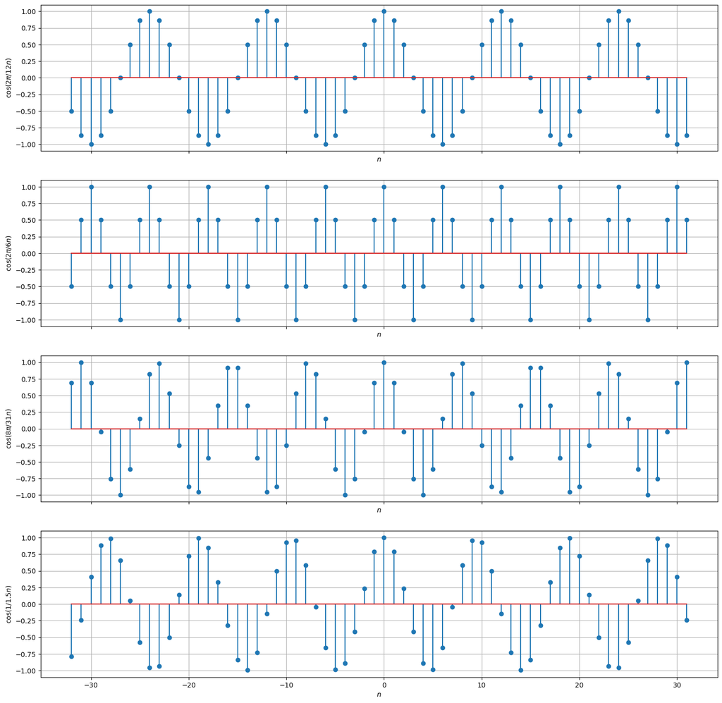

```python
n = np.arange(-32,32,1) # create an evenly spaced integer value array
fig, axes = plt.subplots(4,1,sharex='all',sharey='all', figsize=(18,18))

def dt_sinusoid(amp, omeg0,n):
    """returns a descrete time (DT) sinusoid signal array"""
    return amp*np.cos(omeg0*n)

# create signals
x1n = dt_sinusoid(1,2*np.pi/12,n)
x2n = dt_sinusoid(1,2*np.pi/6,n)
x3n = dt_sinusoid(1,8*np.pi/31,n)
x4n = dt_sinusoid(1,1/1.5,n)

# create plots
# plot xn1
axes[0].stem(n,x1n)
axes[0].set_xlabel('$n$')
axes[0].set_ylabel(r'$\cos(2\pi /12 n)$')
axes[0].grid(True)

# plot xn2
axes[1].stem(n,x2n)
axes[1].set_xlabel('$n$')
axes[1].set_ylabel(r'$\cos(2\pi /6 n)$')
axes[1].grid(True)

# plot xn3
axes[2].stem(n,x3n)
axes[2].set_xlabel('$n$')
axes[2].set_ylabel(r'$\cos(8\pi /31 n)$')
axes[2].grid(True)

# plot xn4
axes[3].stem(n,x4n)
axes[3].set_xlabel('$n$')
axes[3].set_ylabel(r'$\cos(1/1.5 n)$')
axes[3].grid(True)

plt.show()
```

Periodic signals  
$x_1 [n] = \cos((2\pi /12) n)$  
$x_2 [n] = \cos((2\pi /6) n)$  
$x_3 [n] = \cos((8\pi /31) n)$

Aperiodic signal  
$x_4 [n] = \cos((1/1.5) n)$

# 1.6 General Complex Exponential Signals

Plotting the real part of $x[n] = C\alpha^n$ with $C = |C|e^{j\theta}$, $\alpha = |\alpha|e^{j\omega _0}$  
$\Re(x[n]) = |C||\alpha|^n \cos(\omega _0 n +\theta) $

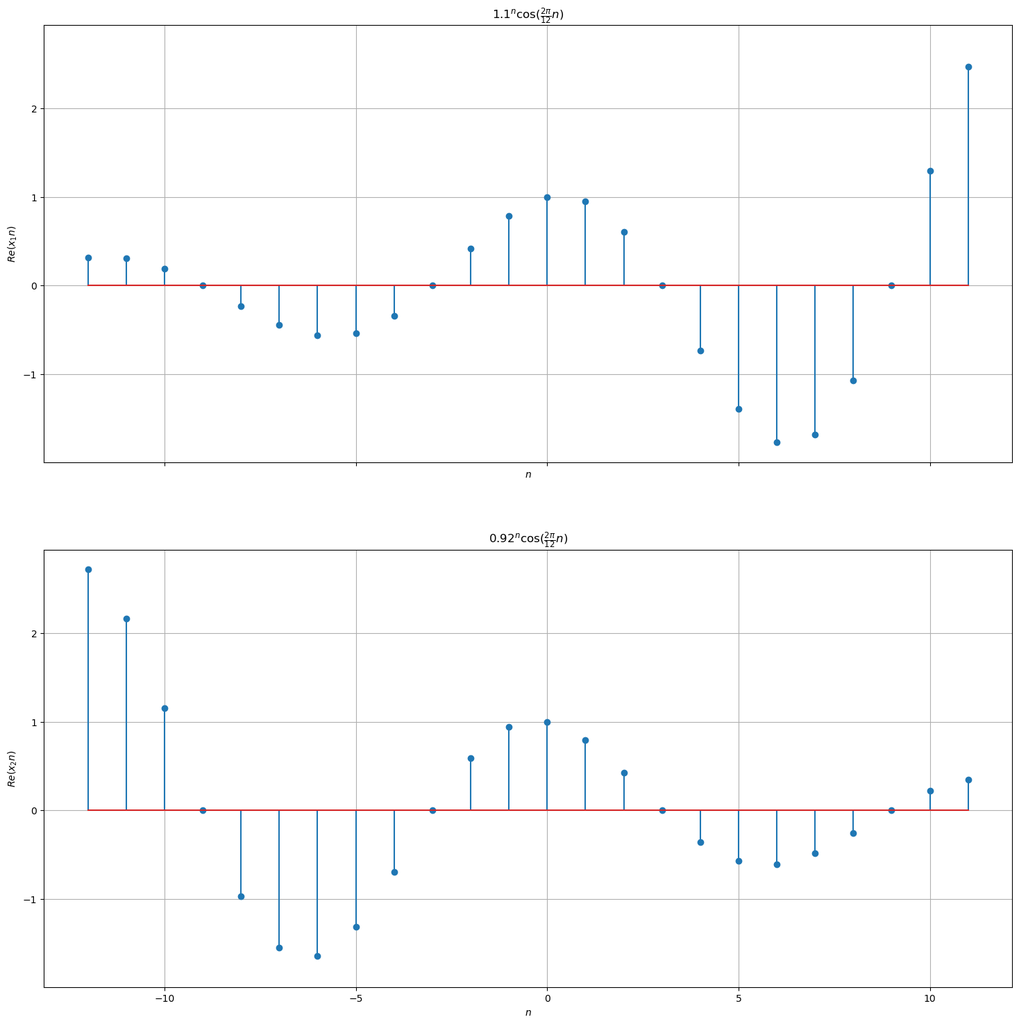

```python
n = np.arange(-12,12,1) # an evenely spaced integer array
fig, axes = plt.subplots(2,1, sharex='all',sharey='all', figsize=(18,18))
theta = 0.0

def real_of_complex_exp(c,alpha,n, omega0,theta):
    """returns an arrray of the real part of a complex exponential signal"""
    return abs(c)*(abs(alpha)**n)*np.cos(omega0*n+theta)

# create signals
re_x1n = real_of_complex_exp(1,1.1,n,2*np.pi/12,theta)
re_x2n = real_of_complex_exp(1,0.92,n,2*np.pi/12,theta)

# create plots
# plot xn1
axes[0].stem(n,re_x1n)
axes[0].set_xlabel('$n$')
axes[0].set_ylabel('$Re(x_1 n)$')
axes[0].title.set_text(r'$1.1^n \cos( \frac{2 \pi}{12} n)$')
axes[0].grid(True)

# plot xn2
axes[1].stem(n,re_x2n)
axes[1].set_xlabel('$n$')
axes[1].set_ylabel('$Re(x_2 n)$')
axes[1].title.set_text(r'$0.92^n \cos( \frac{2 \pi}{12} n)$')
axes[1].grid(True)

plt.show()
```

### Effect due to negative alpha

$\alpha = -|\alpha|e^{j\omega_0}$ i.e. When $\alpha$ is negative,  
$x[n]=C \alpha^n = (-1)^n|C||\alpha|^n(\cos(\omega _0 n+\theta)+j\sin(\omega _0 n+\theta))$  
Below lets plot the real part of the negative $\alpha$ function.

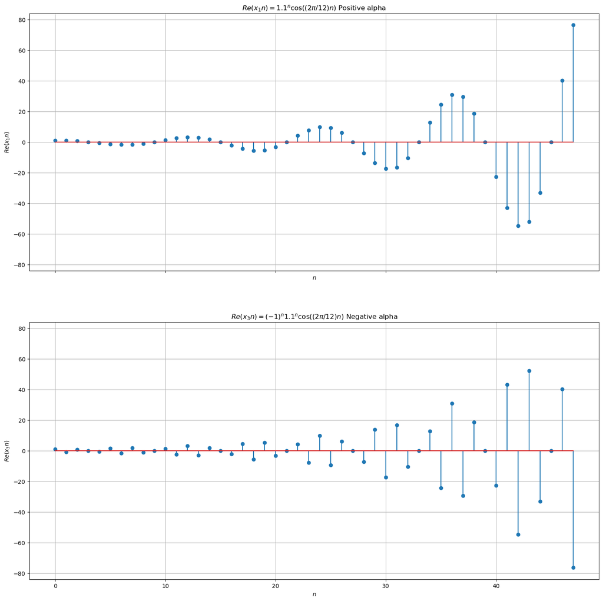

```python
n = np.arange(0,48,1) # evenly spaced integer array
fig, axes = plt.subplots(2,1, sharex='all',sharey='all', figsize=(18,18))

# create signals
re_x1n = real_of_complex_exp(1,1.1,n,2*np.pi/12,theta) # positive alpha signal
re_x3n = ((-1)**n)*real_of_complex_exp(1,-1.1,n,2*np.pi/12,theta) #negative alpha signal

# create plots
# plot xn1
axes[0].stem(n,re_x1n)
axes[0].set_xlabel('$n$')
axes[0].set_ylabel(r'$Re(x_1 n)$')
axes[0].title.set_text(r'$Re(x_1 n)=1.1^n \cos((2 \pi /12) n)$ Positive alpha')
axes[0].grid(True)

# plot xn2
axes[1].stem(n,re_x3n)
axes[1].set_xlabel('$n$')
axes[1].set_ylabel(r'$Re(x_3 n)$')
axes[1].title.set_text(r'$Re(x_3 n)=(-1)^n 1.1^n \cos((2 \pi /12) n)$ Negative alpha')
axes[1].grid(True)

plt.show()
```

If $\alpha$ is negative, the signal oscillates between negative and positive values alternatively; however, the magnitude of the corresponding amplitude remains unchanged.

# 1.7 Transformation of the Independent Variable

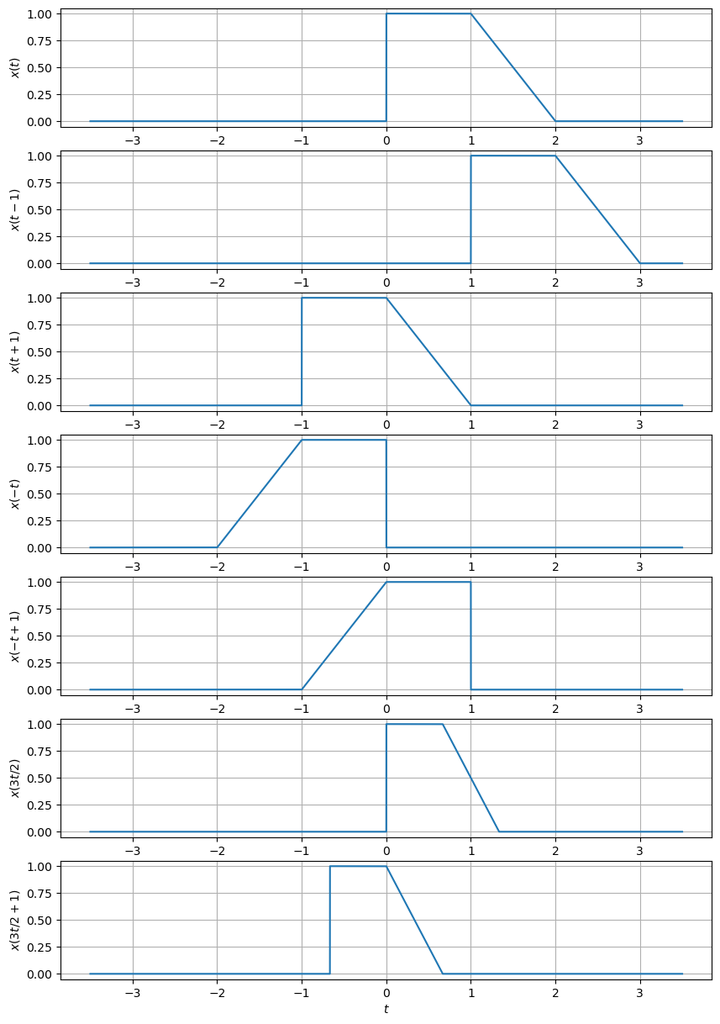

```python
def x(t):
    """returns the values of a piecewise function"""
    if (t < 0.):
        return 0
    elif (t < 1.):
        return 1
    elif (t < 2.):
        return (2. - t)
    else:
        return 0.

fs = 4.4e4 # sampling frequency
ts = 1/fs # sampling period
t = np.arange(-3.5, 3.5, ts) # A linearly−spaced array with step ts
fig, axes = plt.subplots(7,1, sharey='all', figsize=(10,15))

# x(t)
axes[0].plot(t, [x(t_) for t_ in t])
axes[0].set_xlabel('$t$')
axes[0].set_ylabel('$x(t)$')
axes[0].grid(True)

# x(t-1)
axes[1].plot(t, [x(t_-1) for t_ in t])
axes[1].set_xlabel('$t$')
axes[1].set_ylabel('$x(t-1)$')
axes[1].grid(True)

# x(t+1)
axes[2].plot(t, [x(t_+1) for t_ in t])
axes[2].set_xlabel('$t$')
axes[2].set_ylabel('$x(t+1)$')
axes[2].grid(True)

# x(-t)
axes[3].plot(t, [x(-t_) for t_ in t])
axes[3].set_xlabel('$t$')
axes[3].set_ylabel('$x(-t)$')
axes[3].grid(True)

# x(-t+1)
axes[4].plot(t, [x(-t_+1) for t_ in t])
axes[4].set_xlabel('$t$')
axes[4].set_ylabel('$x(-t+1)$')
axes[4].grid(True)

# x(3t/2)
axes[5].plot(t, [x(3*t_/2) for t_ in t])
axes[5].set_xlabel('$t$')
axes[5].set_ylabel('$x(3t/2)$')
axes[5].grid(True)

# x(3t/2+1)
axes[6].plot(t, [x(3*t_/2+1) for t_ in t])
axes[6].set_xlabel('$t$')
axes[6].set_ylabel('$x(3t/2+1)$')
axes[6].grid(True)

plt.show()
```

# 1.8 Observing a Signal in Frequency Domain

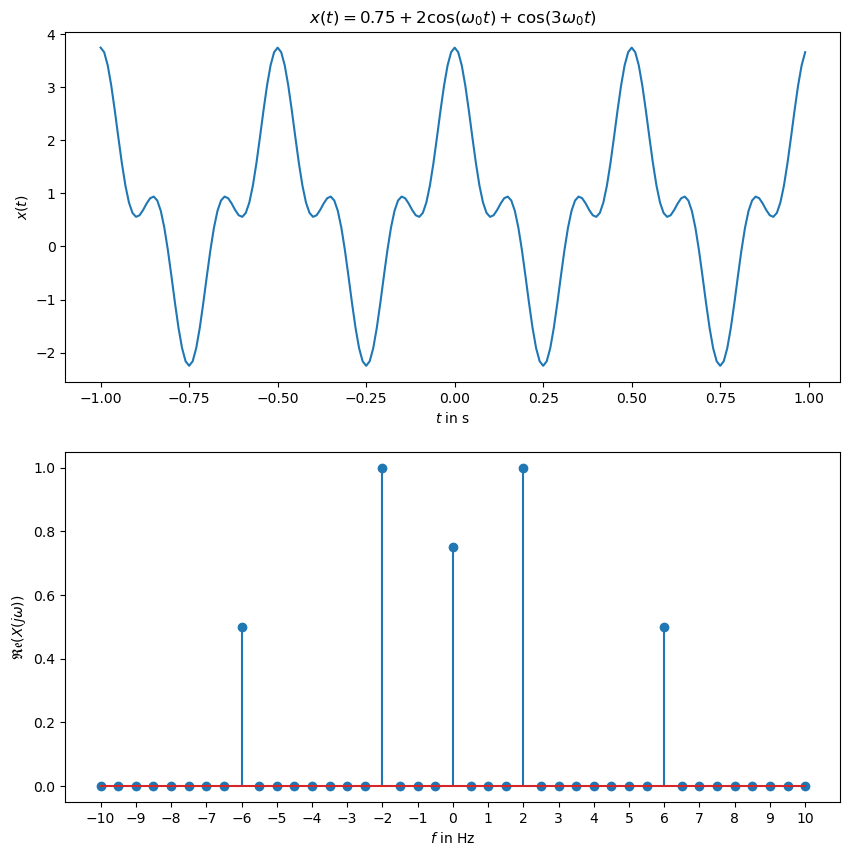

```python
fs = 100 # sampling frequency
ts = 1/fs # sampling period
t = np.arange(-1., 1., ts) # a linearly−spaced array with step ts for time axis
fig, axes = plt.subplots(2,1, figsize=(10,10))

f = 2 # 2 Hz frequency for the signal
omega0 = 2*np.pi*f # angular frequency

xt = 0.75 + 2.*np.cos(omega0*t) + 1.*np.cos(3*omega0*t) # signal in the time domain
Xf = np.fft.fft(xt) # signal in the frequency domain
freq = np.fft.fftfreq(t.shape[-1], d=ts) # frequency axis values from the transformation

# plot the signal in time domain
axes[0].plot(t,xt)
# axes[0].plot(t,2.*np.cos(omega0*t)) # building blocks
# axes[0].plot(t,np.cos(3*omega0*t)) # building blocks
axes[0].set_xlabel('$t$ in s')
axes[0].set_ylabel('$x(t)$')
axes[0].title.set_text(r'$x(t)=0.75+2\cos(\omega _0t)+\cos(3\omega _0t)$')

# ranges of x_axis and y_axis for the frequency domain representation
valsubrange = np.concatenate((np.arange(0,21,1), np.arange(-1,-21,-1)))
freqsubrage = np.concatenate((np.arange(0,21,1), np.arange(-1,-21,-1)))

# plot the signal in the frequency domain
axes[1].stem(freq[freqsubrage], Xf.real[valsubrange]/len(t)) # plot real part of freq domain signal against freq
axes[1].set_xlabel('$f$ in Hz')
axes[1].set_ylabel(r'$\mathfrak{Re}(X(j\omega))$')
plt.xticks(np.arange(-10,11))

plt.show()
```

### Interpretation

The periodic signal $x(t)$ is in the time domain and when FFT fast fourier transform is applied we get the frequency domain representation. The independent variable is frequency and the dependent variable shows the amplitude. Since $x(t)$ is periodic the fourier transform is discrete. Fourier tranform of cosine $cos(2\pi f_0 t)$ is $\frac{\delta(f-f_0)+\delta(f+f_0)}{2}$. For frequencies 0, 2, 6 the amplitude is 0.75, 1, 0.5 respectively and otherwise 0.

# 1.9 Simple Audio Effects